# Problema de la lata de conserva

Para abordar este problema mediante algoritmos genéticos, consideramos genotipos de números reales de longitud $2N = 6$ representando soluciones en las que el diámetro de la lata es la media de los $N = 3$ primeros genes y la altura de la lata es la media de los $N = 3$ últimos genes.

```r
obten_fenotipo <- function(genotipo) {
  diametro <- mean(genotipo[seq_len(params$N)])
  altura <- mean(genotipo[-seq_len(params$N)])
  c(`Diámetro` = diametro, Altura = altura)
}
```

Como valor de aptitud de cada genotipo consideramos una combinación ponderada de las dos funciones objetivo a optimizar. Podría ocurrir que los valores de una de esas funciones fueran de mayor magnitud que los de la otra función, quedando anulados los segundos por los primeros. Para evitar este problema normalizamos al intervalo $(0, 1)$ los valores de ambas funciones. Además, puesto que el algoritmo genético implementado en el paquete `GA` trata de maximizar el valor de aptitud, transformamos el objetivo de minimizar la superficie de la lata por el objetivo de maximizar la diferencia entre $S$ y la superficie de la lata, donde $S$ es la máxima superficie posible.

```r
calcula_volumen <- function(fenotipo) {
  diametro <- fenotipo[[1]]
  altura <- fenotipo[[2]]
  pi * diametro^2 * altura / 4
}

maximo_volumen <- calcula_volumen(c(20, 30))

calcula_superficie <- function(fenotipo) {
  diametro <- fenotipo[[1]]
  altura <- fenotipo[[2]]
  pi * diametro^2 / 2 + pi * diametro * altura
}

maxima_superficie <- calcula_superficie(c(20, 30))

funcion_fitness <- function(genotipo) {
  fenotipo <- obten_fenotipo(genotipo)
  volumen <- calcula_volumen(fenotipo)
  volumen_normalizado <- volumen / maximo_volumen
  superficie <- calcula_superficie(fenotipo)
  superficie_normalizada <- superficie / maxima_superficie
  params$peso_volumen * volumen_normalizado +
    params$peso_superficie * (1 - superficie_normalizada)
}
```

Estamos ya entonces en condiciones de poder abordar el problema mediante algoritmos genéticos. Hay que tener en cuenta que un problema de optimización multiobjetivo no tiene soluciones óptimas globales, por lo que la solución encontrada por el algoritmo depende en gran medida de los pesos considerados para cada función objetivo, que en este caso son $1$ para el volumen de la lata y $1$ para la superficie de la lata.

```r
library(GA)
library(purrr)

ultima_generacion <-
  ga(type = "real-valued",
     lower = rep(10, times = 2 * params$N), # Mínimo valor posible para cada gen
     upper = rep(c(20, 30), each = params$N), # Máximo valor posible para cada gen
     fitness = funcion_fitness,
     popSize = 1000,
     monitor = TRUE)
```

```
## GA | iter = 1 | Mean = 0.8633496 | Best = 0.9379482
## GA | iter = 2 | Mean = 0.8671563 | Best = 0.9379482
## GA | iter = 3 | Mean = 0.8717579 | Best = 0.9379482
## GA | iter = 4 | Mean = 0.8774720 | Best = 0.9379482
## GA | iter = 5 | Mean = 0.8829029 | Best = 0.9379482
## GA | iter = 6 | Mean = 0.8882064 | Best = 0.9379482
## GA | iter = 7 | Mean = 0.8936095 | Best = 0.9379482
## GA | iter = 8 | Mean = 0.8997759 | Best = 0.9379482
## GA | iter = 9 | Mean = 0.9060236 | Best = 0.9379482
## GA | iter = 10 | Mean = 0.9104405 | Best = 0.9470214
## GA | iter = 11 | Mean = 0.9141151 | Best = 0.9473990
## GA | iter = 12 | Mean = 0.9163206 | Best = 0.9473990
## GA | iter = 13 | Mean = 0.9183745 | Best = 0.9473990
## GA | iter = 14 | Mean = 0.9204570 | Best = 0.9476372
## GA | iter = 15 | Mean = 0.9217979 | Best = 0.9476372
## GA | iter = 16 | Mean = 0.9228169 | Best = 0.9476372
## GA | iter = 17 | Mean = 0.9248922 | Best = 0.9488041
## GA | iter = 18 | Mean = 0.9266504 | Best = 0.9488041
## GA | iter = 19 | Mean = 0.9277992 | Best = 0.9488041
## GA | iter = 20 | Mean = 0.9284628 | Best = 0.9526814
## GA | iter = 21 | Mean = 0.9298228 | Best = 0.9526814
## GA | iter = 22 | Mean = 0.9308021 | Best = 0.9531861
## GA | iter = 23 | Mean = 0.9321199 | Best = 0.9531861
## GA | iter = 24 | Mean = 0.9333353 | Best = 0.9531861
## GA | iter = 25 | Mean = 0.9335684 | Best = 0.9531861
## GA | iter = 26 | Mean = 0.9344764 | Best = 0.9551550
## GA | iter = 27 | Mean = 0.9351818 | Best = 0.9554686
## GA | iter = 28 | Mean = 0.9359574 | Best = 0.9554686
## GA | iter = 29 | Mean = 0.9367648 | Best = 0.9566769
## GA | iter = 30 | Mean = 0.9379011 | Best = 0.9566769
## GA | iter = 31 | Mean = 0.9392590 | Best = 0.9566769
## GA | iter = 32 | Mean = 0.9398820 | Best = 0.9566769
## GA | iter = 33 | Mean = 0.9407798 | Best = 0.9573767
## GA | iter = 34 | Mean = 0.9406690 | Best = 0.9573767
## GA | iter = 35 | Mean = 0.9418514 | Best = 0.9573767
## GA | iter = 36 | Mean = 0.9424564 | Best = 0.9592940
## GA | iter = 37 | Mean = 0.9435108 | Best = 0.9597371
## GA | iter = 38 | Mean = 0.9436370 | Best = 0.9597371
## GA | iter = 39 | Mean = 0.9446039 | Best = 0.9608965
## GA | iter = 40 | Mean = 0.9456698 | Best = 0.9608965
```

[output cut: 45 more lines]

```
## GA | iter = 86 | Mean = 0.9612462 | Best = 0.9795229
## GA | iter = 87 | Mean = 0.9627120 | Best = 0.9795229
## GA | iter = 88 | Mean = 0.9632794 | Best = 0.9795229
## GA | iter = 89 | Mean = 0.9631697 | Best = 0.9800157
## GA | iter = 90 | Mean = 0.9634627 | Best = 0.9800157
## GA | iter = 91 | Mean = 0.9637183 | Best = 0.9800157
## GA | iter = 92 | Mean = 0.9643085 | Best = 0.9800157
## GA | iter = 93 | Mean = 0.9648833 | Best = 0.9800157
## GA | iter = 94 | Mean = 0.9648948 | Best = 0.9800157
## GA | iter = 95 | Mean = 0.9646373 | Best = 0.9800157
## GA | iter = 96 | Mean = 0.9642724 | Best = 0.9800157
## GA | iter = 97 | Mean = 0.9638828 | Best = 0.9800157
## GA | iter = 98 | Mean = 0.9654435 | Best = 0.9800157
## GA | iter = 99 | Mean = 0.9661047 | Best = 0.9800157
## GA | iter = 100 | Mean = 0.9668058 | Best = 0.9800157
```

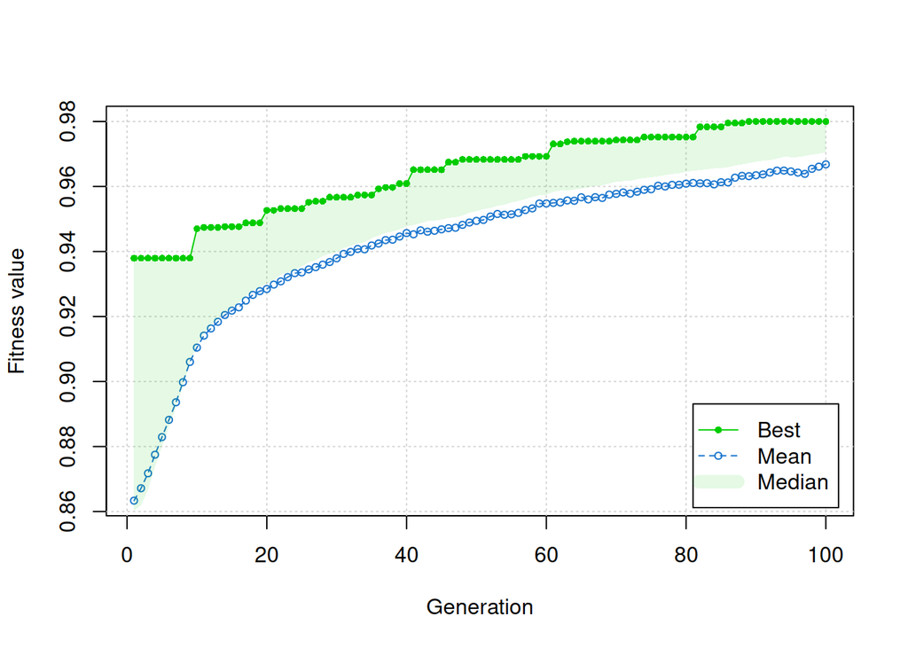

```r
plot(ultima_generacion)
```

```r
summary(ultima_generacion)
```

```
## ── Genetic Algorithm ───────────────────
##
## GA settings:
## Type                  =  real-valued
## Population size       =  1000
## Number of generations =  100
## Elitism               =  50
## Crossover probability =  0.8
## Mutation probability  =  0.1
## Search domain =
##       x1 x2 x3 x4 x5 x6
## lower 10 10 10 10 10 10
## upper 20 20 20 30 30 30
##
## GA results:
## Iterations             = 100
## Fitness function value = 0.9800157
## Solution =
##            x1       x2       x3       x4       x5      x6
## [1,] 19.78331 19.49443 19.63075 29.41415 28.65333 29.3271
```

```r
array_branch(ultima_generacion@solution, margin = 1) |>
  map(obten_fenotipo) |>
  map(\(fenotipo) c(fenotipo,
                    Volumen = calcula_volumen(fenotipo),
                    Superficie = calcula_superficie(fenotipo)))
```

```
## [[1]]
##   Diámetro     Altura    Volumen Superficie
##   19.63616   29.13153 8821.98509 2402.75536
```

**Nota**: este es un documento RMarkdown con parámetros `N`, `peso_volumen` y `peso_superficie`. RStudio permite recompilar fácilmente el documento con distintos valores para esos parámetros.